# Assignment 02 – Random Forest & Stacking

# 6. Split the dataset into the Training set and Test set. Choose your preferred split and justify the rationale. (1)

```python
# Using the remaining columns as the feature set 'X'
X = gr8_CC.drop(['Class'], axis=1 )
# Using the class column as the target variable
y = gr8_CC['Class']

print(X.shape)

print(y.shape)
```

```
(284807, 30)
(284807,)
```

```python
# split train and test dataset
# In this step, I decided to keep 70% of the data for training for and 30% for testing
gr8_CC_X = gr8_CC.loc[:, gr8_CC.columns != 'Class'].to_numpy()
gr8_CC_y = gr8_CC.loc[:, gr8_CC.columns == 'Class'].to_numpy()
gr8_CCX_train, gr8_CCX_test, gr8_CCy_train, gr8_CCy_test = train_test_split(gr8_CC_X,gr8_CC_y, test_size=0.30, random_state=0)
```

## Perform classification routine by using LogisticRegression(), KNeighborsClassifier(), DecisionTreeClassifier(), SVC(), GaussianNB(), RandomForestClassifier(), BaggingClassifier(), GradientBoostingClassifier(), XGboostclassifier. Output the accuracy box plot as we have seen in the class (make sure to change regressmod df to classmod and use an appropriate metric for classification evaluation, for example, accuracy, precision,recall etc). Remember to use the object oriented approach and develop a function (def…), this will be very helpful for the next assignment. (40)

### 7.0 Import the Models

```python
from sklearn.linear_model import LogisticRegression
from sklearn.neighbors import KNeighborsClassifier
from sklearn import svm
from sklearn.tree import DecisionTreeClassifier
from sklearn.ensemble import GradientBoostingClassifier, BaggingClassifier, RandomForestClassifier
from sklearn.naive_bayes import GaussianNB
from sklearn.model_selection import cross_val_score, RepeatedKFold
#Models imported
#!pip install xgboost
# install xgboost module from pip
import xgboost
#import xgboost
from xgboost import XGBClassifier
#import xgboostclassifier
```

### 7.1 Build the Model Functions

```python
# list of models
def base_models():
    models = dict()
    models['lr'] = LogisticRegression()
    models["KN"] = KNeighborsClassifier()
    models["SVC"] = svm.SVC()
    models["Tree"] = DecisionTreeClassifier()
    models["Random Forest"] = RandomForestClassifier()
    models["Bagging"] = BaggingClassifier()
    models["GBM"] = GradientBoostingClassifier()
    models["GNB"] = GaussianNB()
    models["XGB"] = XGBClassifier()
    return models

# Function to evaluate the list of models
def eval_models(model):
    cv = RepeatedKFold(n_splits=10, n_repeats=3, random_state=1)
    scores = -cross_val_score(model, gr8_CCX_train, gr8_CCy_train, scoring='neg_mean_absolute_error', cv=cv, n_jobs=-1, error_score='raise')
    return scores

# evaluate the models and print results
models = base_models()
results, names = list(), list()
for name, model in models.items():
  scores = eval_models(model)
  results.append(scores)
  names.append(name)
  print('>%s %.3f (%.3f)' % (name, scores.mean(), scores.std()))

# store results in dataframe
classmod = pd.DataFrame(np.transpose(results), columns = ["lr","KN","SVC","Tree","Random Forest","Bagging","GBM", "GNB","XGB"])
classmod = pd.melt(classmod.reset_index(), id_vars='index',value_vars=["lr","KN","SVC","Tree","Random Forest","Bagging","GBM", "GNB","XGB"])
```

```
>lr 0.001 (0.000)
>KN 0.002 (0.000)
>SVC 0.002 (0.000)
>Tree 0.001 (0.000)
>Random Forest 0.000 (0.000)
>Bagging 0.001 (0.000)
>GBM 0.001 (0.000)
>GNB 0.007 (0.001)
>XGB 0.000 (0.000)
```

### 7.2 Graph the accuracy plots

```python
#!pip3 install plotly
import plotly.express as px
from plotly.subplots import make_subplots
import plotly.graph_objs as go

fig = px.box(classmod, x="variable", y="value",color="variable",points='all',
labels={"variable": "Machine Learning Model",
        "value": "RMS Error"
        },title="Model Performance")
fig.show()

#Models with best performance are Random Forest, Decision Tree, Bagging and XGB
```

[output not shown]

## 8. Select the best classifier for level 0 classifier. Use logistic regression as a second level classifier. Similar to 7 generate the box plot and show the accuracy of each algorithm as well as stacked classifier. Also show the confusion metrices of the above algorithms .(15)

```python
import seaborn as sns
#from sklearn.datasets import load_boston
import warnings
from sklearn.model_selection import cross_val_score, RepeatedKFold
from sklearn.linear_model import Ridge, Lasso, LinearRegression,LogisticRegression
from sklearn.tree import DecisionTreeClassifier
from sklearn.ensemble import GradientBoostingClassifier, BaggingClassifier,RandomForestClassifier, StackingClassifier
from xgboost import XGBClassifier
from lightgbm import LGBMRegressor
def get_stacking():
# define the base models
    level0 = list()
    level0.append(('Bagging', BaggingClassifier()))
    level0.append(('RF', RandomForestClassifier()))
    level0.append(('Tree', DecisionTreeClassifier()))
    level0.append(('XGB', XGBClassifier()))
# define meta learner model
    level1 = LogisticRegression()
# define the stacking ensemble
    model = StackingClassifier(estimators=level0, final_estimator=level1, cv=5)
    return model
def base_models():
    models = dict()
    models["Bagging"] = BaggingClassifier()
    models["Random Forest"] = RandomForestClassifier()
    models["Tree"] = DecisionTreeClassifier()
    models["XGB"] = XGBClassifier()
    models["Stacked Model"] = get_stacking()
    return models
# Function to evaluate the list of models
def eval_models(model):
    cv = RepeatedKFold(n_splits=10, n_repeats=3, random_state=1)
    scores = -cross_val_score(model, gr8_CCX_train, gr8_CCy_train,
    scoring='neg_mean_absolute_error', cv=cv, n_jobs=-1,
    error_score='raise')
    return scores
models = base_models()
# evaluate the models and store results
results, names = list(), list()
for name, model in models.items():
    scores = eval_models(model)
    results.append(scores)
    names.append(name)
    print('>%s %.3f (%.3f)' % (name, scores.mean(), scores.std()))
classmod = pd.DataFrame(np.transpose(results), columns = ["Tree","Random Forest","Bagging","XGB","Stacked Model"])
classmod = pd.melt(classmod.reset_index(),
id_vars='index',value_vars=["Bagging","Random Forest","Tree","XGB","Stacked Model"])
fig = px.box(classmod, x="variable", y="value",color="variable",points='all',
labels={"variable": "Machine Learning Model","value": "RMS Error"},title="Model Performance")
fig.show()
# fig.write_image("HW3/Boxplot-candidate.jpeg",engine="kaleido",format="png",width=1600, height=700, scale=0.75)fig.show()
## 9. Export the Pickle model and import it back. Use the imported model to predict the y_test from x_test and report the confusion metrix (3)
```

[output not shown]

```
>Bagging 0.001 (0.000)
>Random Forest 0.000 (0.000)
>Tree 0.001 (0.000)
>XGB 0.000 (0.000)
>Stacked Model 0.000 (0.000)
```

```python
gr8_CCX_train
#This line was for debuging (handle the warning)
```

```
array([[ 1.13921000e+05, -1.32066260e-01,  1.07043551e-01, ...,
         3.06394657e-01,  7.48169663e-02,  4.78900000e+01],
       [ 1.35319000e+05,  2.12599441e+00,  1.42074055e-02, ...,
        -6.82673794e-02, -5.76775883e-02,  1.98000000e+00],
       [ 1.25498000e+05, -8.66939700e-02,  1.66240223e-01, ...,
        -1.20157065e+00, -1.13993068e+00,  1.70100000e+02],
       ...,
       [ 7.66160000e+04,  1.51260229e+00, -9.49435315e-01, ...,
        -1.41537086e-03,  3.66494418e-03,  3.49000000e+01],
       [ 9.72530000e+04,  1.79886333e+00, -1.69979073e+00, ...,
        -3.36155803e-02, -3.24705125e-02,  1.71310000e+02],
       [ 7.48870000e+04, -5.89399721e-01,  7.47828393e-01, ...,
         8.65917860e-02,  1.18083774e-01,  1.59900000e+01]])
```

```python
import pickle
#library loaded
gr8_CCy_train = gr8_CCy_train.ravel()
level0 = list()
level0.append(('Tree', DecisionTreeClassifier()))
level0.append(('RF', RandomForestClassifier()))
level0.append(('XGB', XGBClassifier()))
level0.append(('Bagging', BaggingClassifier()))
level1 = LogisticRegression()
model = StackingClassifier(estimators=level0, final_estimator=level1, cv=5)
model.fit(gr8_CCX_train, gr8_CCy_train)
#Save to file in the current working directory
pkl_filename = "AssignmentPickle.pkl"
with open(pkl_filename, 'wb') as file:
    pickle.dump(model, file)
# Load the model from file
with open(pkl_filename, 'rb') as file:
    pickle_model = pickle.load(file)

score = pickle_model.score(gr8_CCX_test, gr8_CCy_test)
print("Test score: {0:.2f} %".format(100 * score))
Y_predict = pickle_model.predict(gr8_CCX_test)
```

```
Test score: 99.95 %
```

```python
import matplotlib.pyplot as plt
from sklearn.metrics import confusion_matrix
predictions = pd.DataFrame(Y_predict, columns=['predictions'])
predictions['actual'] = gr8_CCy_test
print(f'The confusion matrix for the model is: \n {confusion_matrix( gr8_CCy_test, Y_predict.ravel())}')

#Print the confusion matrix below
```

```
The confusion matrix for the model is:
 [[85292     4]
 [   36   111]]
```

## 10. Show both text and visual confusion Matrices using scikit learn and matplotlib and explain what the graph tells you and what you did. (2)

```
<sklearn.metrics._plot.confusion_matrix.ConfusionMatrixDisplay at 0x1f44da3b8e0>
```

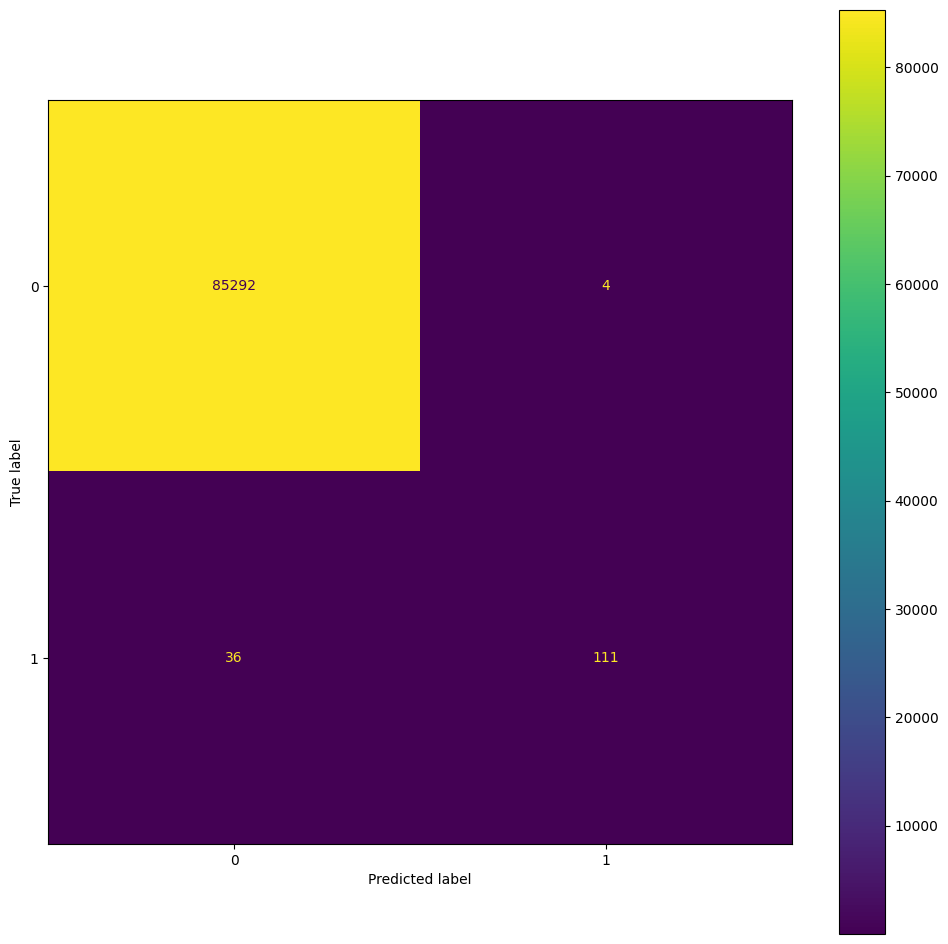

```python
#Graph the confusion matrix
import matplotlib.pyplot as plt
from sklearn.metrics import ConfusionMatrixDisplay
from seaborn import set_palette

plt.figure(figsize=(2.5,2.5),dpi=75)
set_palette("Paired")

G8_conf_matrix = confusion_matrix(gr8_CCy_test, Y_predict)
ConfusionMatrixDisplay.from_estimator(pickle_model, gr8_CCX_test, gr8_CCy_test)

#We print the confusion matrix, the matrix shows that the model performs well in general, especially handeling Fake True data where only 4 fake true got detected. and performs relativity worse on
#detecting Fake False where 36 True got predicted to be false.
```

```python
import plotly.io as pio
pio.renderers.default='notebook'
```